# MiSiPi.RNA Documentation

## The ML table

The misipi_rna module produces a table which is named according to the name of the input BED file, the name of the input BAM file, followed by “_ml.txt”. This table can be used for characterization of your loci of interest, or as input for the machine learning module (ml_probability) tests the probability that a locus has the features of one of the major small RNA pathways.

A brief description of what is being calculated for the columns in the ML table:

**1. Locus name** (the chromosome, start, and end from the BED file).

**2. Length** The length of the locus.

**3. log_shap_p** Log10(Shapiro’s p-value). After calculating the read size distribution, the normality of the distribution is tested using a Shapiro-Wilk’s test. Small RNA-producing loci that are part of major pathways will often have skewed distributions relative to loci with reads generated from random degradation.

**auc** Similar to (3), the area under a curve fit on a normal distribution should be 1, whereas in skewed distributions, the curve will not capture 100% of the data.

**strand_bias** Strand bias. The ratio of reads aligning to sense or antisense. This can help distinguish small RNAs produced from a single stranded precursor versus a bidirectionally transcribed locus or from a foldback structure from an inverted repeat.

**6. perc_GC** The GC nucleotide composition of all the reads.

**7. ave_size** The average read size at the locus

**8. perc_first_nucT** The percentage of reads which have a uracil (T) at the first position in the 5’ end, which is a preference for some small RNA processing enzymes.

**9. perc_A10** Similar to (8) an adenine bias at the tenth position is a characteristic of ping pong piRNA biogenesis.

**10. highest_si_col** This number comes from the siRNA heatmap (See siRNA module). It is the average read size of the most commonly found overlapping read pairs which have a proper 2nt overhang, or in the heatmap, the cell(s) with the highest read density.

**11. si_dicerz** The z-score that is found at “shift 0”, e.g., the probability that the read pairs have a proper 2nt overhang without shifting the read positions (see BioRxiv article for more information about how this is calculated).

**12. num_si_dicer_reads** The number of reads which have a proper 2nt overhang with their overlapping paired read.

**13. hp_perc_paired** When running the hairpin RNA- specific part of the siRNA module, RNAfold is used to fold the genomic sequence and the ratio of bases which are predicted to be paired due to complementarity is compared to the total number of bases.

**14. hp_phasedz** The average Z-score at nucleotides 1-3 for all overlapping read pairs (see BioRxiv for more information about phasing calculations).

**15. hp_mfe** From RNAfold, the minimum free energy calculated for the predicted folded structure.

**16. hp_dicerz** The z-score found at “shift 0” but for overlapping read pairs found by using the predicted paired positions from RNA fold (see BioRxiv article).

**17. mi_perc_paired** The percent of predicted paired nucleotides from RNAfold predictions. This is a separate metric from hp_perc_paired for the event that the locus may not have sufficient data to reach the folding step in one of the programs. For example, a long hpRNA would not be processed by the miRNA module if it exceeds 300nt in length.

**18. mirna_dicerz** The z-score found at “shift 0” but for overlapping read pairs found by using the predicted paired positions from RNA fold, but for miRNAs (see BioRxiv article).

**19. mirna_mfe** The minimum folding energy of the structure predicted by RNAfold from the miRNA module.

**20. mirna_overlapz** For all overlapping read pairs at the locus, the probability of the size of the overlap (for miRNAs, generally ~19nt).

**21. pingpong_col** The average read size of all read pairs overlapping by exactly 10nt (a charateristic of ping pong piRNAs).

**22. max_pi_count** The number of reads from (21).

**23. max_piz_overlap** For all overlapping read pairs at the locus, the overlap length with the highest z-score (e.g. ping pong piRNAs typically have a high probability of a 10nt overlap).

**24. pi_phasedz** For overlapping read pairs, the average z-score from nucleotides 1-3. This is useful for distinguishing phased piRNAs.

**25. pi_phased26z** The same as (24), but for only read pairs > 26nt in length.

**26. unique_read_bias** The number of distinct read start and end positions, which may be useful for distinguishing loci such as miRNAs, simple repeats, or rRNAs.

## Machine Learning

If you have a large list of loci (e.g. from calling clusters) and want to quickly determine which are more likely to be part of the small RNA pathway you are interested in (or not, such as rRNAs, snRNAs, tRNAs, etc.), you can use the output _ml table made from misipi_rna and the ml_probability module to make probability plots for each locus of interest. See the BioRxiv article for more information about how the MiSiPi.RNA machine learning model was made, or Build-A-Model section (coming soon).

```r
#give the path to the directory that contains the folder and the name of the table
ml_probability("full/path/to/table/directory", "table_ml.txt")
```

The ml_probability module will create a subdirectory called “radar_plots” which will contain a probability plot for each locus.

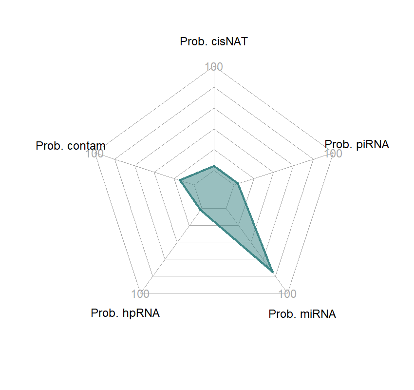